# Digitalis Dataset

# Research question

**Population:** Patients taking digoxin prior to randomization

**Exposure:** Discontinuation of digoxin as per randomization

**Outcome:** Short-term (12 mths) risk / hazard ratio of hospitalization for worsened heart failure. OR Short-term (12 mths) risk / hazard ratio of death due to worsened heart failure.

**Primary study**

The Cox proportional-hazards model was also used to test for interactions between the study assignments and predefined variables that included the left ventricular ejection fraction, heart size, the cause of heart failure (ischemic vs. nonischemic), digoxin use before the trial, and New York Heart Association (NYHA) functional class.

Results: Fewer patients were hospitalized for worsening heart failure in the digoxin group (910) than in the placebo group (1180) (risk ratio, 0.72; 95 percent confidence interval, 0.66 to 0.79; P  0.001)

Table 3: Report subgroup analyses for previous use of digoxin but the outcome is death OR hosp for worsening heart failure.

Discussion: The risk of hospitalization, especially for worsening heart failure, was reduced with digoxin treatment. There were fewer deaths due to worsening heart failure in the digoxin group.

# Censoring

As we only look at short-term we need to right censor our data, meaning that patients with an event after 365 days will be recoded to not having an event. Additionally, any observational days > 365 will be recoded to 365.

## before right censoring

Using random sample of 100 patients

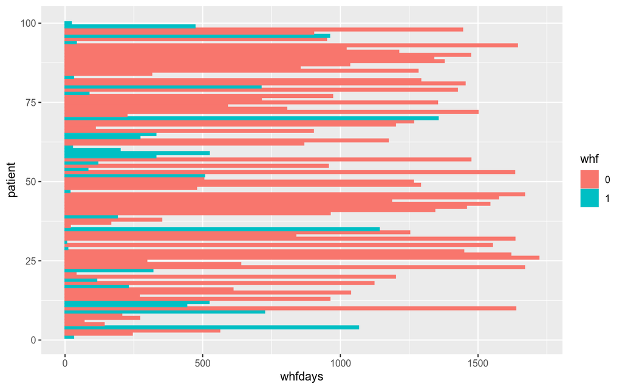

# after right censoring

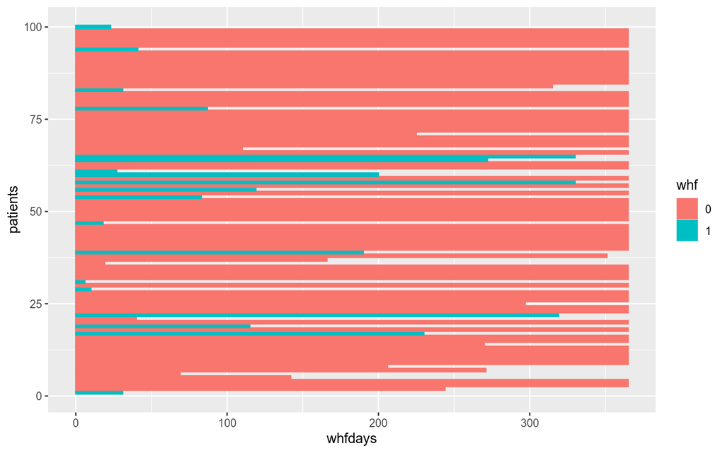

# Table 1

| **Characteristic** | **0**, N = 2,377<sup>1</sup> | **1**, N = 640<sup>1</sup> |
| --- | --- | --- |
| trtmt |  |  |
| 0 | 1,129 (47%) | 390 (61%) |
| 1 | 1,248 (53%) | 250 (39%) |
| calculated: age at randomization | 64 (57, 71) | 64 (57, 71) |
| race |  |  |
| white | 2,038 (86%) | 508 (79%) |
| non-white | 339 (14%) | 132 (21%) |
| sex |  |  |
| male | 1,833 (77%) | 485 (76%) |
| female | 544 (23%) | 155 (24%) |
| q3: ejection fraction (percent) | 29 (22, 35) | 25 (19, 31) |
| q6: chest x-ray (ct-ratio) | 0.52 (0.48, 0.58) | 0.56 (0.51, 0.60) |
| calculated: body mass index (kg/m*m) | 26.5 (23.7, 29.8) | 26.5 (24.1, 29.7) |
| q9a: serum potassium level | 4.30 (4.00, 4.60) | 4.30 (4.10, 4.60) |
| Unknown | 292 | 78 |
| q9: serum creatinine (mg/dl) | 1.21 (1.03, 1.46) | 1.21 (1.07, 1.42) |
| q12: duration of chf (months) | 17 (5, 42) | 16 (5, 40) |
| Unknown | 5 | 0 |
| rales |  |  |
| None or unknown | 668 (28%) | 181 (28%) |
| Present | 151 (6.4%) | 42 (6.6%) |
| Past | 1,292 (54%) | 359 (56%) |
| Present and Past | 266 (11%) | 58 (9.1%) |
| elevjvp |  |  |
| None or unknown | 1,126 (47%) | 257 (40%) |
| Present | 130 (5.5%) | 47 (7.3%) |
| Past | 914 (38%) | 287 (45%) |
| Present and Past | 207 (8.7%) | 49 (7.7%) |
| pedema |  |  |
| None or unknown | 1,174 (49%) | 279 (44%) |

[output cut: 104 more lines]

<sup>*1*</sup> n (%); Median (IQR)

# Non-parametric Survival Curve Estimation

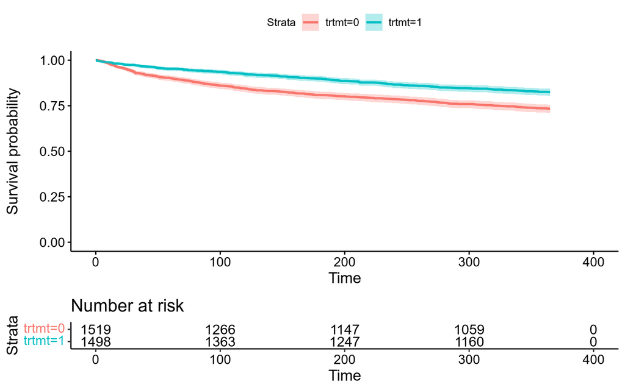

```
Call:
survdiff(formula = surv_obj ~ trtmt, data = subgroup_censored)

           N Observed Expected (O-E)^2/E (O-E)^2/V
trtmt=0 1519      390      311      20.1      39.2
trtmt=1 1498      250      329      19.0      39.2

 Chisq= 39.2  on 1 degrees of freedom, p= 4e-10
```

# Cox PH

## crude model

| **Characteristic** | **HR**<sup>1</sup> | **95% CI**<sup>1</sup> | **p-value** |
| --- | --- | --- | --- |
| trtmt | 0.61 | 0.52, 0.71 | <0.001 |

<sup>*1*</sup> HR = Hazard Ratio, CI = Confidence Interval

## With covariates

| **Characteristic** | **HR**<sup>1</sup> | **95% CI**<sup>1</sup> | **p-value** |
| --- | --- | --- | --- |
| trtmt | 0.62 | 0.53, 0.72 | <0.001 |
| calculated: age at randomization | 1.00 | 0.99, 1.01 | >0.9 |
| race |  |  |  |
| white | — | — |  |
| non-white | 1.36 | 1.12, 1.65 | 0.002 |
| sex |  |  |  |
| male | — | — |  |
| female | 1.13 | 0.94, 1.35 | 0.2 |
| calculated: body mass index (kg/m*m) | 1.00 | 0.98, 1.01 | >0.9 |
| q3: ejection fraction (percent) | 0.96 | 0.95, 0.97 | <0.001 |
| q9: serum creatinine (mg/dl) | 1.00 | 0.82, 1.23 | >0.9 |
| calculated: sum of q13-q20, y/n status | 1.07 | 0.96, 1.19 | 0.2 |
| diabetes |  |  |  |
| 0 | — | — |  |
| 1 | 1.09 | 0.92, 1.29 | 0.3 |
| aceinhib |  |  |  |
| 0 | — | — |  |
| 1 | 1.42 | 0.95, 2.14 | 0.089 |
| nitrates |  |  |  |
| 0 | — | — |  |
| 1 | 1.04 | 0.89, 1.22 | 0.6 |
| hydral |  |  |  |
| 0 | — | — |  |
| 1 | 1.59 | 1.05, 2.39 | 0.028 |
| diuretk |  |  |  |
| 0 | — | — |  |
| 1 | 0.98 | 0.75, 1.29 | >0.9 |

<sup>*1*</sup> HR = Hazard Ratio, CI = Confidence Interval

## Variable selection based on AIC

| **Characteristic** | **HR**<sup>1</sup> | **95% CI**<sup>1</sup> | **p-value** |
| --- | --- | --- | --- |
| trtmt |  |  |  |
| 0 | — | — |  |
| 1 | 0.61 | 0.52, 0.72 | <0.001 |
| race |  |  |  |
| white | — | — |  |
| non-white | 1.38 | 1.13, 1.67 | 0.001 |
| q3: ejection fraction (percent) | 0.96 | 0.95, 0.97 | <0.001 |
| aceinhib |  |  |  |
| 0 | — | — |  |
| 1 | 1.43 | 0.95, 2.15 | 0.085 |
| hydral |  |  |  |
| 0 | — | — |  |
| 1 | 1.59 | 1.05, 2.39 | 0.027 |

<sup>*1*</sup> HR = Hazard Ratio, CI = Confidence Interval

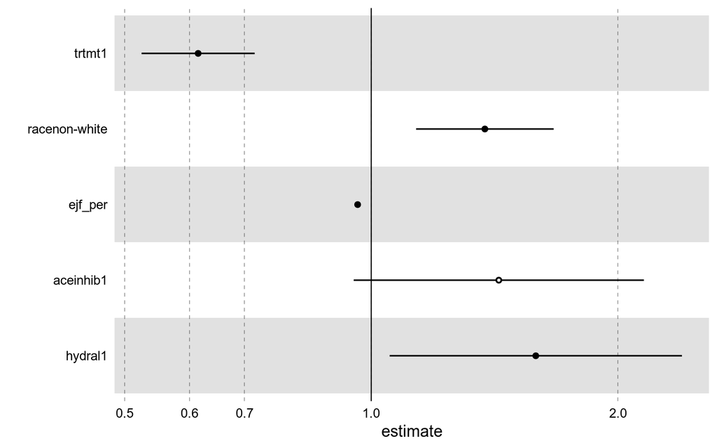

# Death from WHF < 365 days as outcome

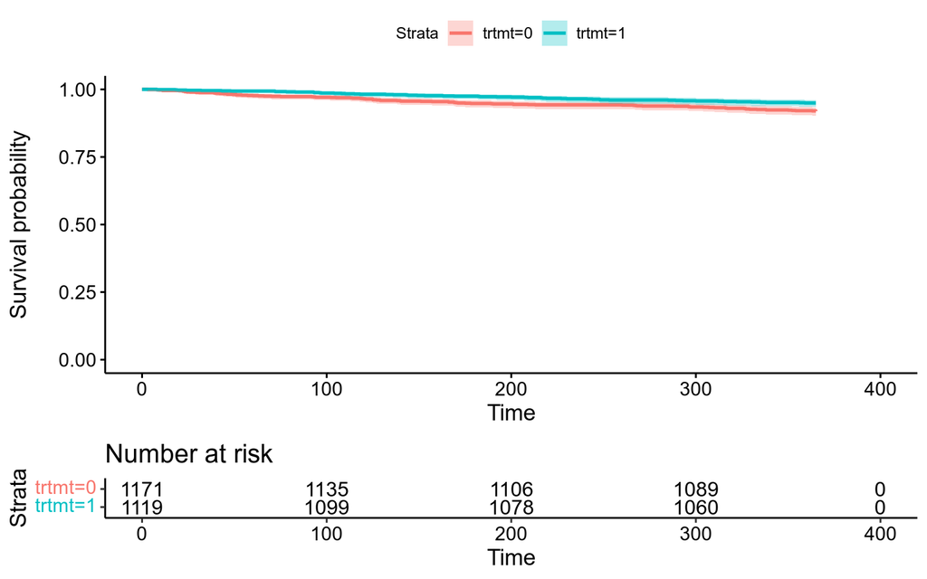

```
Call:
survdiff(formula = Surv(time = deathday, event = death) ~ trtmt,
    data = whf_death)

           N Observed Expected (O-E)^2/E (O-E)^2/V
trtmt=0 1171       94     76.1      4.19      8.52
trtmt=1 1119       56     73.9      4.32      8.52

 Chisq= 8.5  on 1 degrees of freedom, p= 0.004
```

## Crude coxph

| **Characteristic** | **HR**<sup>1</sup> | **95% CI**<sup>1</sup> | **p-value** |
| --- | --- | --- | --- |
| trtmt | 0.61 | 0.44, 0.85 | 0.004 |

<sup>*1*</sup> HR = Hazard Ratio, CI = Confidence Interval

## With covariates

| **Characteristic** | **HR**<sup>1</sup> | **95% CI**<sup>1</sup> | **p-value** |
| --- | --- | --- | --- |
| trtmt | 0.62 | 0.45, 0.87 | 0.005 |
| calculated: age at randomization | 1.01 | 0.99, 1.02 | 0.5 |
| race |  |  |  |
| white | — | — |  |
| non-white | 0.86 | 0.54, 1.35 | 0.5 |
| sex |  |  |  |
| male | — | — |  |
| female | 1.29 | 0.90, 1.85 | 0.2 |
| q3: ejection fraction (percent) | 0.94 | 0.92, 0.96 | <0.001 |
| calculated: body mass index (kg/m*m) | 1.00 | 0.97, 1.03 | 0.8 |
| q9: serum creatinine (mg/dl) | 0.90 | 0.57, 1.41 | 0.6 |
| calculated: sum of q13-q20, y/n status | 1.02 | 0.82, 1.28 | 0.8 |
| diabetes |  |  |  |
| 0 | — | — |  |
| 1 | 0.89 | 0.62, 1.29 | 0.5 |
| aceinhib |  |  |  |
| 0 | — | — |  |
| 1 | 0.79 | 0.40, 1.55 | 0.5 |
| nitrates |  |  |  |
| 0 | — | — |  |
| 1 | 1.12 | 0.81, 1.55 | 0.5 |
| hydral |  |  |  |
| 0 | — | — |  |
| 1 | 2.74 | 1.38, 5.43 | 0.004 |
| diuretk |  |  |  |
| 0 | — | — |  |
| 1 | 1.04 | 0.61, 1.78 | 0.9 |

<sup>*1*</sup> HR = Hazard Ratio, CI = Confidence Interval

## Variable selection based on AIC

| **Characteristic** | **HR**<sup>1</sup> | **95% CI**<sup>1</sup> | **p-value** |
| --- | --- | --- | --- |
| trtmt |  |  |  |
| 0 | — | — |  |
| 1 | 0.63 | 0.45, 0.87 | 0.006 |
| q3: ejection fraction (percent) | 0.94 | 0.92, 0.96 | <0.001 |
| hydral |  |  |  |
| 0 | — | — |  |
| 1 | 2.60 | 1.33, 5.11 | 0.005 |

<sup>*1*</sup> HR = Hazard Ratio, CI = Confidence Interval

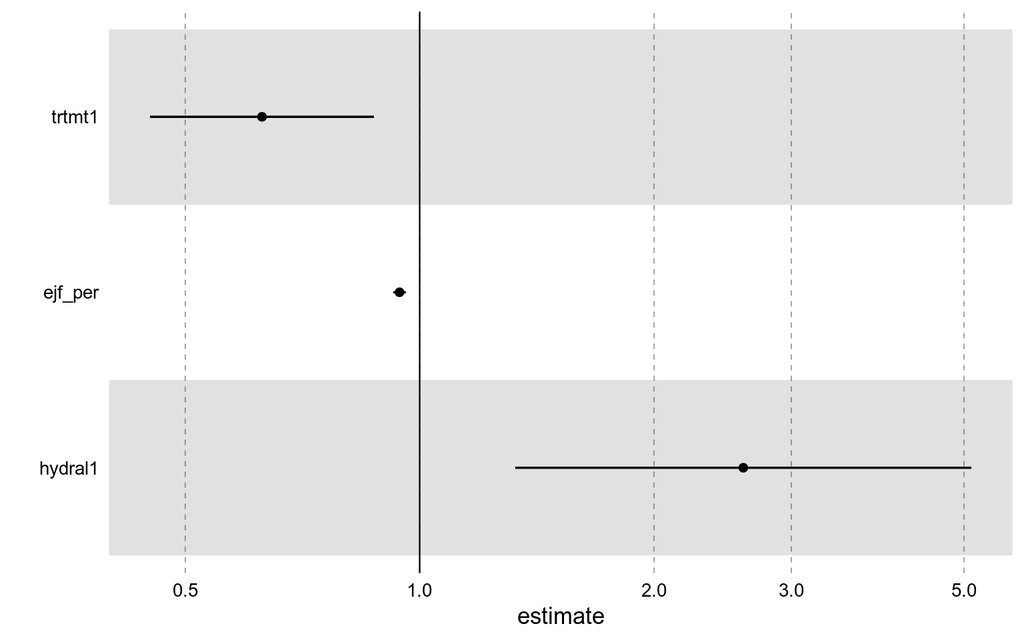

## PH assumption test

```
         chisq df    p
trtmt   1.3968  1 0.24
ejf_per 2.1776  1 0.14
hydral  0.0999  1 0.75
GLOBAL  3.8231  3 0.28
```

## linearity test of ejf_per using penalized splines

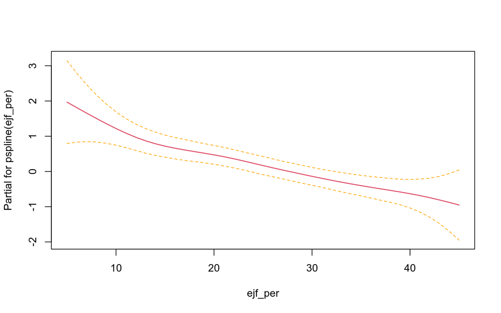